# CHP Data Analysis

Josh Pepper

March 9, 2016

# 1 Introduction

This file is intended to describe the analysis of the [CHP SWITRS data set](http://iswitrs.chp.ca.gov/Reports/jsp/userLogin.jsp) and display maps and results of the analysis. The following data is for the City of Oakland for the years 2013-14.

# 2 Summary statistics

- Number of rows in the data set: *3564*
- Number of columns in the data set: *86*
- Names of columns in the data set:
  - CASEID, POINT_X, POINT_Y, YEAR_, LOCATION, CHPTYPE, DAYWEEK, CRASHSEV, VIOLCAT, KILLED, INJURED, WEATHER1, PEDCOL, BICCOL, MCCOL, TRUCKCOL, ETOH, TIMECAT, MONTH_, CRASHTYP, INVOLVE, PED, PRIMARYRD, SECONDRD, DISTANCE, DIRECT, INTERSECT_, PROCDATE, JURIS, DATE_, TIME_, BADGE, JURIDIST, SHIFT, POP, SPECIAL, BEATTYPE, LAPDDIV, BEATCLAS, BEATNUMB, WEATHER2, STATEHW, CALTRANC, CALTRAND, STROUTE, ROUTESUF, POSTPRE, POSTMILE, LOCATYPE, RAMP, SIDEHW, TOWAWAY, PARTIES, PCF, VIOLCODE, VIOL, VIOLSUB, HITRUN, ROADSURF, RDCOND1, RDCOND2, LIGHTING, RIGHTWAY, CHPRDTYP, NOTPRIV, STFAULT, CHPFAULT, SEVINJ, OTHERINJ, COP, PEDKILL, PEDINJ, BICKILL, BICINJ, MCKILL, MCINJURE, RAMP1, RAMP2, CITY, COUNTY, STATE, X_CHP, Y_CHP, lat, long, date
- More information on each column and its possible values can be found in the SWITRS Codebook.

## 2.1 Incidents by Month

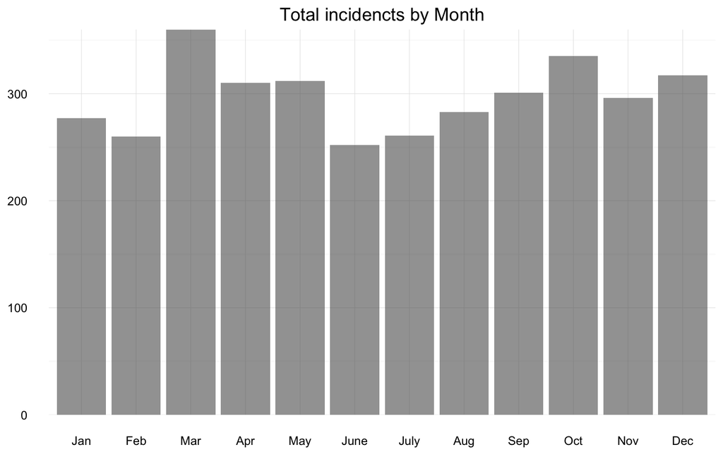

## 2.2 Incidents by day of week

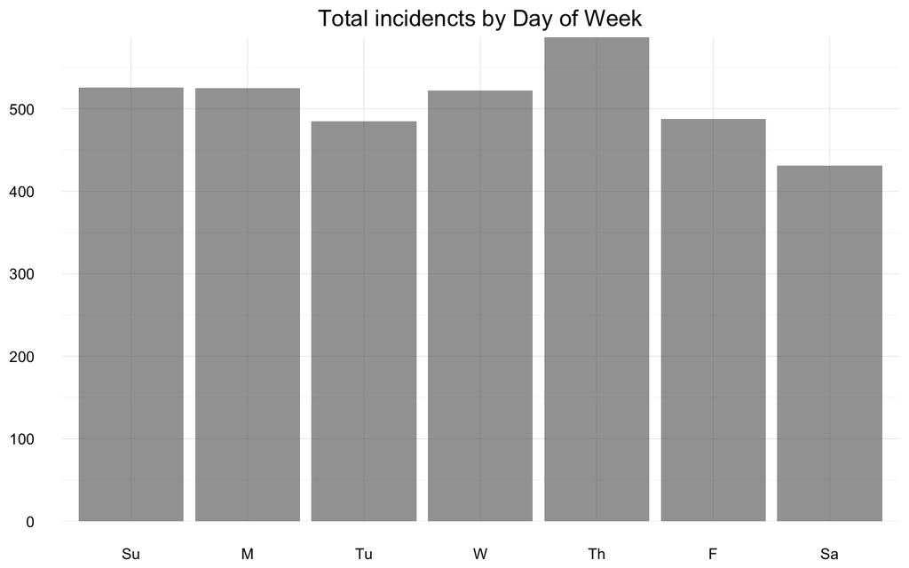

## 2.3 Incidents by time of day

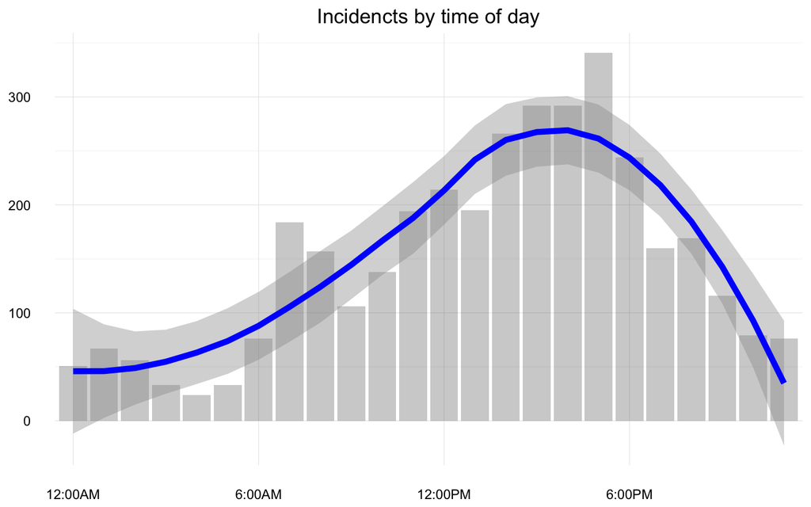

# 3 First map

Map of all CHP citation in Oakland from 1/1/2013-12/31/2014:

[interactive chart not shown]

# 4 Bicyclist data

Notice how one of the columns is titled `BICINJ`. We can map a subset of this data and color code it based on time of accident. I also added a link to more information about each accident using data from the UC Berkeley [Transportation Injury Mapping System (TIPS)](http://tims.berkeley.edu/index.php). TIPS has a [pretty good mapping tool](http://tims.berkeley.edu/tools/gismap/index.php) as well.

[interactive chart not shown]

# 5 Alcohol use data

This map uses the field `ETOH`, which indicates whether the collision involved a party that had been drinking. It’s color-coded by night/day and you can see how most of the alcohol-related collisions occur at night.

[interactive chart not shown]